# ManyBabies Habituation Project

## 2.2 Plots of Crude Effects

### 2.2.1 Habituation by Age

I will use the age variable that I previously created by harmonizing the two variables age_group_new and age_days

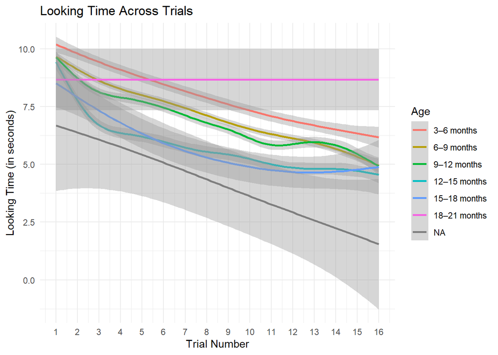

```r
ggplot(data %>% dplyr::filter(testing_trial > 0),
       aes(x = testing_trial, y = looking_time, color = age)) +
  geom_smooth(se = TRUE) +
  scale_color_discrete(
    name = "Age"
  ) +
  labs(
    x = "Trial Number",
    y = "Looking Time (in seconds)",
    title = "Looking Time Across Trials"
  ) +
  scale_x_continuous(
    breaks = seq(1, max(data$testing_trial, na.rm = TRUE), by = 1)
  ) +
  theme_minimal()
```

The plot looks strange: Lets check, how many observations are in each age group in the testing trials!

```r
data %>%
  dplyr::filter(testing_trial > 0) %>%
  dplyr::count(age)
```

```
# A tibble: 8 × 2
  age              n
  <fct>        <int>
1 < 3 months       6
2 3–6 months    5942
3 6–9 months   18194
4 9–12 months  14039
5 12–15 months 10811
6 15–18 months   575
7 18–21 months    52
8 <NA>            16
```

There are few observations in 15-18 and 18-21 months. I will remove NA category for plotting, and add 15-21 months into a single category to make the sample bigger.

```r
data <- data %>%
  mutate(
    new_age = forcats::fct_collapse(
      age,
      `15–21 months` = c("15–18 months", "18–21 months")
    )
  )

# check new age-variable
data %>%
  dplyr::filter(testing_trial > 0) %>%
  dplyr::count(new_age)
```

```
# A tibble: 7 × 2
  new_age          n
  <fct>        <int>
1 < 3 months       6
2 3–6 months    5942
3 6–9 months   18194
4 9–12 months  14039
5 12–15 months 10811
6 15–21 months   627
7 <NA>            16
```

Plot again with new variable and without NA group (16 observations), with 95% confidence intervals

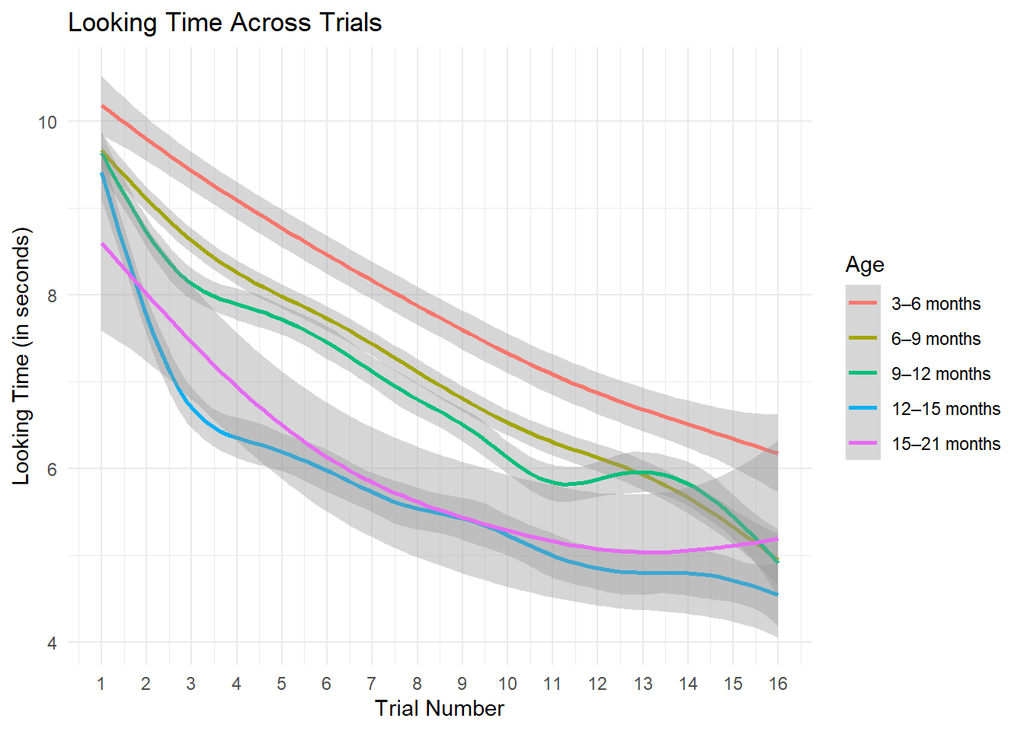

```r
ggplot(data %>% dplyr::filter(testing_trial > 0, !is.na(age) ),
       aes(x = testing_trial, y = looking_time, color = new_age)) +
  geom_smooth(se = TRUE, level = 0.95) +
  scale_color_discrete(
    name = "Age"
  ) +
  labs(
    x = "Trial Number",
    y = "Looking Time (in seconds)",
    title = "Looking Time Across Trials"
  ) +
  scale_x_continuous(
    breaks = seq(1, max(data$testing_trial, na.rm = TRUE), by = 1)
  ) +
  theme_minimal()
```

### 2.2.2 Habituation by Sex of Participant

There seems to be no sex difference overall! Maybe if we stratify the data by other factors later on.

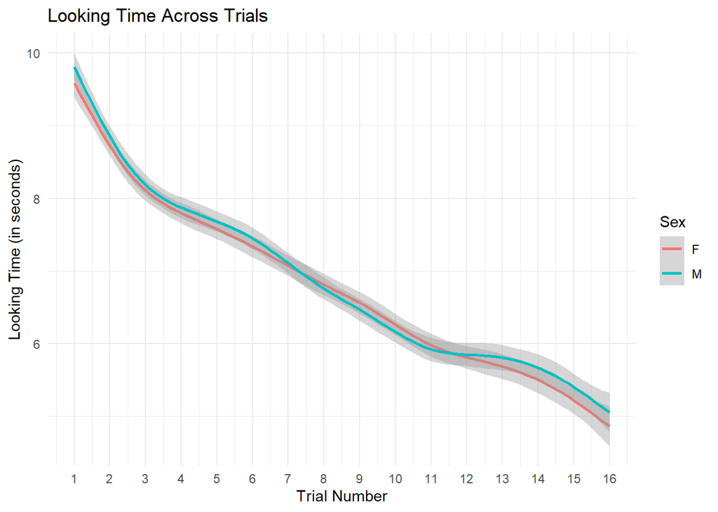

```r
ggplot(data %>% dplyr::filter(testing_trial > 0, !is.na(participant_sex) ),
       aes(x = testing_trial, y = looking_time, color = participant_sex)) +
  geom_smooth(se = TRUE) +
  scale_color_discrete(
    name = "Sex"
  ) +
  labs(
    x = "Trial Number",
    y = "Looking Time (in seconds)",
    title = "Looking Time Across Trials"
  ) +
  scale_x_continuous(
    breaks = seq(1, max(data$testing_trial, na.rm = TRUE), by = 1)
  ) +
  theme_minimal()
```

### 2.2.3 Habituation by Gender of Primary Caregiver

```r
# check amount of data per category
data %>%
dplyr::filter(testing_trial > 0) %>%
dplyr::count(primarycaregiver_gender)
```

```
# A tibble: 5 × 2
  primarycaregiver_gender     n
  <fct>                   <int>
1 F                       44388
2 M                        4457
3 other                      71
4 OTHER                       4
5 <NA>                      715
```

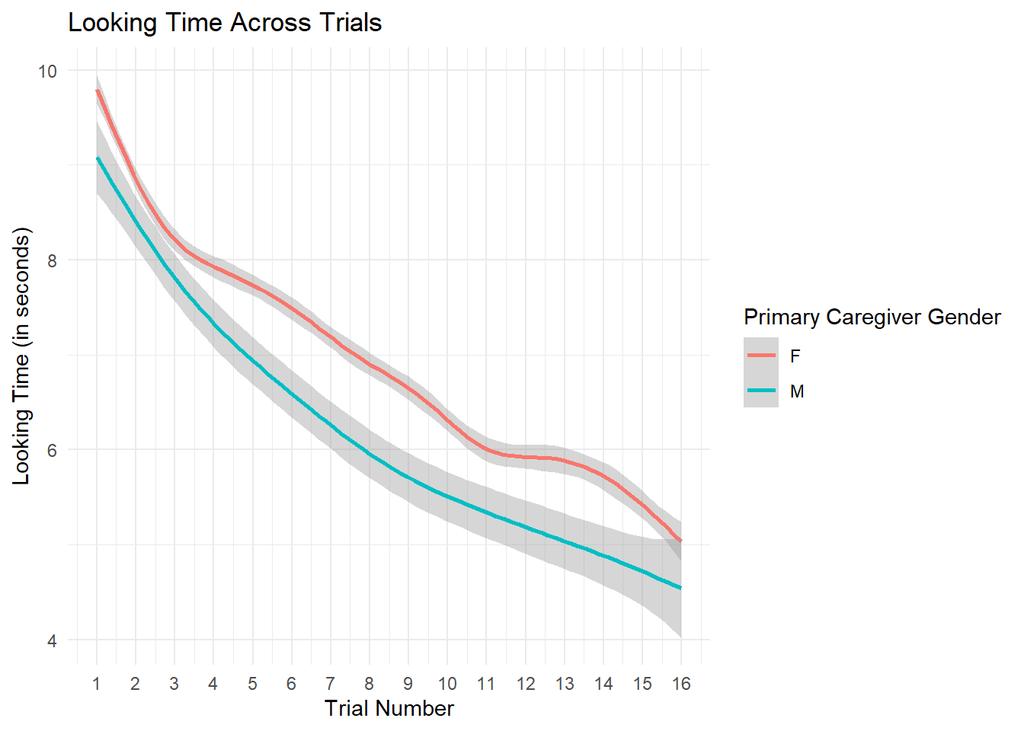

```r
# "other" and "OTHER" are just 75 observations, compared to 44000 F and 4500 M, remove "other" due to severely missing data for plotting

ggplot(data %>% dplyr::filter(
         !is.na(primarycaregiver_gender),
         !primarycaregiver_gender %in% c("other", "OTHER")),
       aes(x = testing_trial, y = looking_time, color = primarycaregiver_gender)) +
  geom_smooth(se = TRUE, level = 0.95) +
  scale_color_discrete(
    name = "Primary Caregiver Gender"
  ) +
  labs(
    x = "Trial Number",
    y = "Looking Time (in seconds)",
    title = "Looking Time Across Trials"
  ) +
  scale_x_continuous(
    breaks = seq(1, max(data$testing_trial, na.rm = TRUE), by = 1)
  ) +
  theme_minimal()
```

### 2.2.4 Habituation by Language Group

```r
# check amount of data per category
data %>%
dplyr::filter(testing_trial > 0) %>%
dplyr::count(language_group)
```

```
# A tibble: 4 × 2
  language_group     n
  <fct>          <int>
1 bilingual       6262
2 monolingual    42847
3 other             71
4 <NA>             455
```

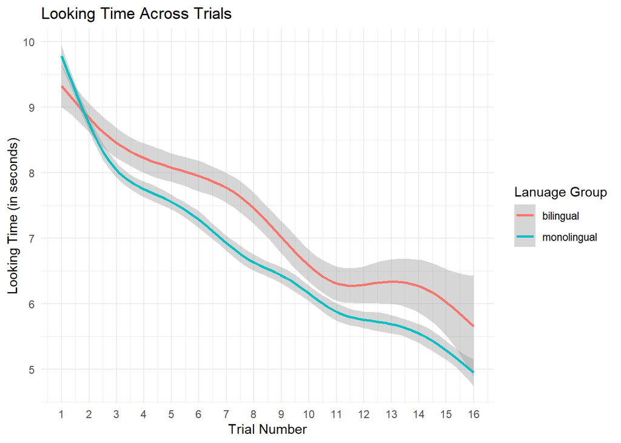

```r
# "other" and "OTHER" are just 71 observations, remove them for plotting

ggplot(data %>% dplyr::filter(!is.na(language_group),
                              !language_group %in% c("other")),
       aes(x = testing_trial, y = looking_time, color = language_group)) +
          geom_smooth(se = TRUE, level = 0.95) +
          scale_color_discrete(
            name = "Lanuage Group"
          ) +
          labs(
            x = "Trial Number",
            y = "Looking Time (in seconds)",
            title = "Looking Time Across Trials"
          ) +
          scale_x_continuous(
            breaks = seq(1, max(data$testing_trial, na.rm = TRUE), by = 1)
          ) +
          theme_minimal()
```

## 2.3 Main model: Demographic moderators of the habituation trajectory

To evaluate whether demographic variables (household size, language background, age, sex, and caregiver gender) modulate the habituation trajectory, we employed a confirmatory model-testing strategy. We first fitted a comprehensive ‘full’ model incorporating these factors as fixed effects and their interactions with the trial number (modeled via natural splines, $df=4$). We then utilized the drop1 procedure and AIC comparison to evaluate whether the inclusion of these parameters significantly improved model fit compared to a parsimonious baseline model (the habituation trajectory alone). This approach ensures that we do not overfit our models with demographic predictors that do not account for meaningful variance in infant looking time.

```r
# Define all predictors you plan to use in Q2
q2_vars <- c("looking_time", "testing_trial", "unique_subject_identifier", "age",
              "participant_sex", "language_group",
             "household_size_z", "parent1_education", "race", "project_id", "lab_id", "stimulus_id", "primarycaregiver_gender")

# Check which variables are missing
missing_q2_vars <- setdiff(q2_vars, names(data_model))
missing_q2_vars
```

```
character(0)
```

```r
# add missing variable household size
data_model <- data_model %>%
  dplyr::mutate(
    household_size_z = as.numeric(scale(household_size))
  )

# Create a subset with no NAs in these specific columns
data_q2_complete <- data_model %>%
  dplyr::select(all_of(q2_vars)) %>%
  na.omit()

# Check how many observations you have left
nrow(data_q2_complete)
```

```
[1] 6282
```

```r
#1 Full model (using complete dataset)

# We use ns(testing_trial, 4) to maintain consistency with the Q1/Q3 spline model
model_q2_dropped <- lmer(
  log1p(looking_time) ~ ns(testing_trial, 4) * language_group +
                        ns(testing_trial, 4) * household_size_z +
                        age +
                        participant_sex +
                        primarycaregiver_gender +
                        (1 | project_id) + (1 | lab_id) + (1 | stimulus_id) + (1 | unique_subject_identifier),
  data = data_q2_complete,
  control = lmerControl(optimizer = "bobyqa")
)

# Use summary to see the results of all predictors at once
summary(model_q2_dropped)
```

```
Linear mixed model fit by REML. t-tests use Satterthwaite's method [
lmerModLmerTest]
Formula: log1p(looking_time) ~ ns(testing_trial, 4) * language_group +
    ns(testing_trial, 4) * household_size_z + age + participant_sex +
    primarycaregiver_gender + (1 | project_id) + (1 | lab_id) +
    (1 | stimulus_id) + (1 | unique_subject_identifier)
   Data: data_q2_complete
Control: lmerControl(optimizer = "bobyqa")

REML criterion at convergence: 9876.1

Scaled residuals:
    Min      1Q  Median      3Q     Max
-4.4743 -0.6339 -0.0167  0.6718  3.6625

Random effects:
 Groups                    Name        Variance  Std.Dev.
 unique_subject_identifier (Intercept) 1.159e-01 3.404e-01
 stimulus_id               (Intercept) 4.983e-03 7.059e-02
 lab_id                    (Intercept) 7.704e-02 2.776e-01
 project_id                (Intercept) 4.362e-14 2.089e-07
 Residual                              2.363e-01 4.861e-01
Number of obs: 6282, groups:
unique_subject_identifier, 489; stimulus_id, 24; lab_id, 20; project_id, 2

Fixed effects:
                                                  Estimate Std. Error
(Intercept)                                      2.132e+00  1.055e-01
ns(testing_trial, 4)1                           -3.310e-01  7.810e-02
ns(testing_trial, 4)2                           -3.507e-01  1.076e-01
ns(testing_trial, 4)3                           -1.052e+00  1.962e-01
ns(testing_trial, 4)4                           -8.382e-01  3.150e-01
language_groupmonolingual                       -4.315e-02  7.874e-02
household_size_z                                -3.028e-02  2.650e-02
age6–9 months                                   -5.558e-02  5.429e-02
age9–12 months                                  -8.446e-02  5.658e-02
age12–15 months                                 -9.722e-02  6.588e-02
age15–18 months                                 -3.169e-01  2.317e-01
participant_sexM                                -5.133e-03  3.385e-02
primarycaregiver_genderM                         1.315e-01  6.667e-02
```

[output cut: 17 more lines]

```
age9–12 months                                   4.429e+02  -1.493  0.13618
age12–15 months                                  4.628e+02  -1.476  0.14068
age15–18 months                                  4.431e+02  -1.368  0.17207
participant_sexM                                 4.385e+02  -0.152  0.87953
primarycaregiver_genderM                         4.394e+02   1.972  0.04923 *
ns(testing_trial, 4)1:language_groupmonolingual  5.756e+03   0.117  0.90674
ns(testing_trial, 4)2:language_groupmonolingual  5.818e+03  -0.614  0.53893
ns(testing_trial, 4)3:language_groupmonolingual  5.857e+03   0.826  0.40860
ns(testing_trial, 4)4:language_groupmonolingual  5.932e+03   1.350  0.17710
ns(testing_trial, 4)1:household_size_z           5.785e+03  -0.917  0.35909
ns(testing_trial, 4)2:household_size_z           5.791e+03   1.396  0.16266
ns(testing_trial, 4)3:household_size_z           5.795e+03   1.567  0.11719
ns(testing_trial, 4)4:household_size_z           5.844e+03   0.864  0.38787
---
Signif. codes:  0 '***' 0.001 '**' 0.01 '*' 0.05 '.' 0.1 ' ' 1
```

```
optimizer (bobyqa) convergence code: 0 (OK)
boundary (singular) fit: see help('isSingular')
```

```r
#We dropped from the full model to the reduced model with the key predictors
drop1(model_q2_dropped, test = "Chisq")
```

```
Single term deletions using Satterthwaite's method:

Model:
log1p(looking_time) ~ ns(testing_trial, 4) * language_group + ns(testing_trial, 4) * household_size_z + age + participant_sex + primarycaregiver_gender + (1 | project_id) + (1 | lab_id) + (1 | stimulus_id) + (1 | unique_subject_identifier)
                                       Sum Sq Mean Sq NumDF  DenDF F value
age                                   0.95451 0.23863     4  444.9  1.0099
participant_sex                       0.00543 0.00543     1  438.5  0.0230
primarycaregiver_gender               0.91892 0.91892     1  439.4  3.8889
ns(testing_trial, 4):language_group   0.58938 0.14735     4 5777.0  0.6236
ns(testing_trial, 4):household_size_z 1.66656 0.41664     4 5808.7  1.7632
                                       Pr(>F)
age                                   0.40192
participant_sex                       0.87953
primarycaregiver_gender               0.04923 *
ns(testing_trial, 4):language_group   0.64568
ns(testing_trial, 4):household_size_z 0.13328
---
Signif. codes:  0 '***' 0.001 '**' 0.01 '*' 0.05 '.' 0.1 ' ' 1
```

```r
#Final reduced model below

model_q2_final <- lmer(
  log1p(looking_time) ~
                        ns(testing_trial, 4)  +
                        (1 | project_id) + (1 | lab_id) + (1 | stimulus_id) + (1 | unique_subject_identifier),
  data = data_q2_complete,
  control = lmerControl(optimizer = "bobyqa")
)
```

## 2.4 Model comparison

We compare our hypothesis-driven “Full” model against the baseline “Reduced” model

```r
model_comparison <- AIC(model_q2_dropped, model_q2_final)
print(model_comparison)
```

```
                 df      AIC
model_q2_dropped 26 9928.121
model_q2_final   10 9852.665
```

While our baseline model ($m0$) effectively captures the habituation trajectory, we wanted to ensure these results hold true across different participant backgrounds. To do this, we conducted a sensitivity analysis. We took our baseline model and systematically added demographic variables—such as age, language, and household size—one by one. We then compared these expanded models against our baseline to see if the new variables actually improved our ability to predict looking times. This process allows us to confirm that the observed habituation patterns are robust and not driven by demographic differences.

## 2.5 Sensitivity analysis: Individual moderator tests

```r
# 0. Base Model (The standardized habituation shape)
m0 <- lmer(log1p(looking_time) ~ ns(testing_trial, 4) + (1 | project_id) + (1 | lab_id) + (1 | stimulus_id) + (1 | unique_subject_identifier),
           data = data_q2_complete, REML = FALSE, control = lmerControl(optimizer = "bobyqa"))

# 1. Household Size (Main Effect)
m1 <- update(m0, . ~ . + household_size_z)
anova(m0, m1)
```

```
Data: data_q2_complete
Models:
m0: log1p(looking_time) ~ ns(testing_trial, 4) + (1 | project_id) + (1 | lab_id) + (1 | stimulus_id) + (1 | unique_subject_identifier)
m1: log1p(looking_time) ~ ns(testing_trial, 4) + (1 | project_id) + (1 | lab_id) + (1 | stimulus_id) + (1 | unique_subject_identifier) + household_size_z
   npar    AIC    BIC  logLik -2*log(L)  Chisq Df Pr(>Chisq)
m0   10 9830.3 9897.8 -4905.1    9810.3
m1   11 9831.7 9905.9 -4904.9    9809.7 0.5912  1      0.442
```

```r
# 2. Household Size (Interaction)
m1a <- update(m0, . ~ . + ns(testing_trial, 4) * household_size_z)
anova(m0, m1a)
```

```
Data: data_q2_complete
Models:
m0: log1p(looking_time) ~ ns(testing_trial, 4) + (1 | project_id) + (1 | lab_id) + (1 | stimulus_id) + (1 | unique_subject_identifier)
m1a: log1p(looking_time) ~ ns(testing_trial, 4) + (1 | project_id) + (1 | lab_id) + (1 | stimulus_id) + (1 | unique_subject_identifier) + household_size_z + ns(testing_trial, 4):household_size_z
    npar    AIC    BIC  logLik -2*log(L)  Chisq Df Pr(>Chisq)
m0    10 9830.3 9897.8 -4905.1    9810.3
m1a   15 9832.6 9933.7 -4901.3    9802.6 7.7427  5      0.171
```

```r
# 3. Age (Main Effect)
m2 <- update(m0, . ~ . + age)
anova(m0, m2)
```

```
Data: data_q2_complete
Models:
m0: log1p(looking_time) ~ ns(testing_trial, 4) + (1 | project_id) + (1 | lab_id) + (1 | stimulus_id) + (1 | unique_subject_identifier)
m2: log1p(looking_time) ~ ns(testing_trial, 4) + (1 | project_id) + (1 | lab_id) + (1 | stimulus_id) + (1 | unique_subject_identifier) + age
   npar    AIC    BIC  logLik -2*log(L)  Chisq Df Pr(>Chisq)
m0   10 9830.3 9897.8 -4905.1    9810.3
m2   14 9834.6 9929.0 -4903.3    9806.6 3.7253  4     0.4445
```

```r
# 4. Participant Sex (Main Effect)
m3 <- update(m0, . ~ . + participant_sex)
anova(m0, m3)
```

```
Data: data_q2_complete
Models:
m0: log1p(looking_time) ~ ns(testing_trial, 4) + (1 | project_id) + (1 | lab_id) + (1 | stimulus_id) + (1 | unique_subject_identifier)
m3: log1p(looking_time) ~ ns(testing_trial, 4) + (1 | project_id) + (1 | lab_id) + (1 | stimulus_id) + (1 | unique_subject_identifier) + participant_sex
   npar    AIC    BIC  logLik -2*log(L)  Chisq Df Pr(>Chisq)
m0   10 9830.3 9897.8 -4905.1    9810.3
m3   11 9832.3 9906.5 -4905.1    9810.3 0.0331  1     0.8556
```

```r
# 5. Language Group (Main Effect)
m4 <- update(m0, . ~ . + language_group)
anova(m0, m4)
```

```
Data: data_q2_complete
Models:
m0: log1p(looking_time) ~ ns(testing_trial, 4) + (1 | project_id) + (1 | lab_id) + (1 | stimulus_id) + (1 | unique_subject_identifier)
m4: log1p(looking_time) ~ ns(testing_trial, 4) + (1 | project_id) + (1 | lab_id) + (1 | stimulus_id) + (1 | unique_subject_identifier) + language_group
   npar    AIC    BIC  logLik -2*log(L)  Chisq Df Pr(>Chisq)
m0   10 9830.3 9897.8 -4905.1    9810.3
m4   11 9831.6 9905.8 -4904.8    9809.6 0.7382  1     0.3902
```

```r
m5 <- update(m0, . ~ . + ns(testing_trial, 4) *language_group)
anova(m0, m5)
```

```
Data: data_q2_complete
Models:
m0: log1p(looking_time) ~ ns(testing_trial, 4) + (1 | project_id) + (1 | lab_id) + (1 | stimulus_id) + (1 | unique_subject_identifier)
m5: log1p(looking_time) ~ ns(testing_trial, 4) + (1 | project_id) + (1 | lab_id) + (1 | stimulus_id) + (1 | unique_subject_identifier) + language_group + ns(testing_trial, 4):language_group
   npar    AIC    BIC  logLik -2*log(L)  Chisq Df Pr(>Chisq)
m0   10 9830.3 9897.8 -4905.1    9810.3
m5   15 9837.1 9938.3 -4903.5    9807.1 3.2109  5     0.6675
```

## 2.6 Visualization of language group trajectories

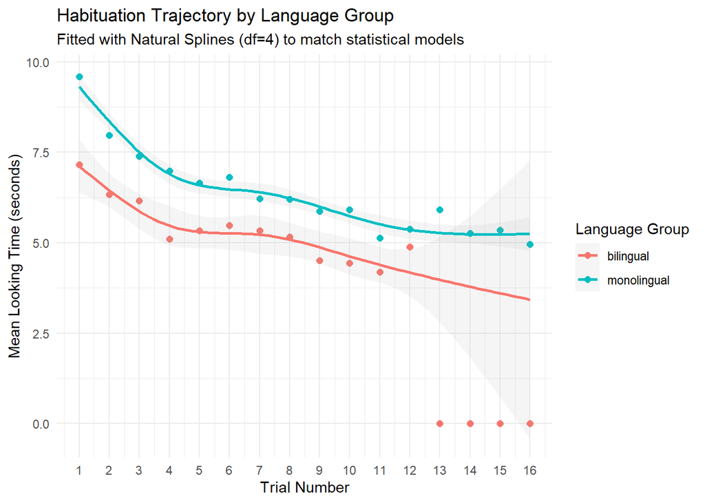

```r
# --- VISUALIZING HABITUATION BY LANGUAGE GROUP ---
# We compare the habituation curves of monolingual and bilingual infants.
# We use natural splines (df=4) to ensure the visual lines match the
# statistical models we tested earlier.

ggplot(data_q2_complete, aes(x = testing_trial, y = looking_time, color = language_group)) +
# 1. Plot raw group means for each trial
  stat_summary(fun = mean, geom = "point", size = 2) +
# 2. Add the non-linear spline trend for each group
  geom_smooth(method = "lm",
              formula = y ~ splines::ns(x, df = 4),
              se = TRUE,
              alpha = 0.1) +
# 3. Label for clarity
    labs(
    x = "Trial Number",
    y = "Mean Looking Time (seconds)",
    color = "Language Group",
    title = "Habituation Trajectory by Language Group",
    subtitle = "Fitted with Natural Splines (df=4) to match statistical models"
  ) +
  # 4. Ensure each trial number is labeled on the x-axis
  scale_x_continuous(breaks = 1:max(data_q2_complete$testing_trial)) +
  theme_minimal()
```

# 3 RQ3 - Methodological effects

Assess how methodological choices influence results.

- 3.1 Do differences contribute to variability?
- 3.2 Do they affect interpretation?
- 3.3 Do they affect reliability?

This analysis investigates **Research Question 3**: “Do methodological and measurement choices influence the estimation and interpretation of infant habituation?”. We specifically examine the **seating arrangement** (`caregiver_seat`), comparing infants in a **caregiver’s lap** (89.5% of observations) to those **sitting alone** (10.3%).

The goal is to determine if seating affects habituation while accounting for infant age, the experimental method used (e.g., Eye-tracking vs. HPP vs. Single-screen), and project-level differences across ManyBabies 1, 3, and 4.

## 3.1 Data Preparation and Zero-Inflation Handling

As noted in the MB project sources, infant looking times are often **zero-inflated**. To address this and meet project requirements for standardized coefficients, we: 1. **Filter trials:** Focus only on valid testing trials (`testing_trial > 0`). 2. **Clean seating:** Remove “changed_throughout” (n=54) and missing values. 3. **Log-transform:** Create `log_looking_time` to handle skew. 4. **Scale:** Standardize `age_days` and `testing_trial` to produce $\beta$ coefficients.

```r
# Load the raw data
data <- read.csv("final_merged_manybabies.csv")

age_levels <- c(
  "< 3 months", "3–6 months", "6–9 months", "9–12 months",
  "12–15 months", "15–18 months", "18–21 months", "> 21 months"
)

data_rq3 <- data %>%
  # STEP A: Create testing trial
  dplyr::mutate(
    testing_trial = ifelse(trial_number > 0, trial_number, NA_real_)
  ) %>%

  # STEP B: Create age variable
  dplyr::mutate(
    age_cut = cut(
      age_days,
      breaks = c(0, 90, 180, 270, 365, 455, 545, 635, Inf),
      labels = age_levels,
      right = FALSE
    ),
    age = dplyr::coalesce(
      as.character(age_group_new),
      as.character(age_cut)
    ),
    age = factor(age, levels = age_levels)
  ) %>%

  # STEP C: Collapse sparse age groups
  dplyr::mutate(
    age_group_clean = dplyr::case_when(
      as.character(age) %in% c("15–18 months", "18–21 months") ~ "15–21 months",
      TRUE ~ as.character(age)
    ),
    age_group_clean = factor(age_group_clean)
  ) %>%

  # STEP D: Filter data
  dplyr::filter(
    !trial_type %in% c("TRAIN", "fam"),
    !is.na(age),
    !is.na(looking_time),
    !is.na(caregiver_seat),
    caregiver_seat != "changed_throughout"
  ) %>%

  # STEP E: Final formatting
  dplyr::mutate(
    caregiver_seat = factor(
      caregiver_seat,
      levels = c("caregiver_lap_only", "seat_alone_only"),
      labels = c("Caregiver Lap", "Sitting Alone")
    ),
    method = factor(
      method,
      levels = c("eyetracking", "hpp", "singlescreen")
    ),
    trial_type = factor(trial_type),
    age_sc = as.numeric(scale(age_days)),
    trial_sc = as.numeric(scale(testing_trial)),
    household_size_z = as.numeric(scale(household_size)),
    log_lt = log1p(looking_time)
  )
```

## 3.2 Descriptive overview of methodological variables

```r
# check amount of data per category
data_rq3 %>%
dplyr::filter(testing_trial > 0) %>%
dplyr::count(trial_type)
```

```
    trial_type     n
1          ADS 16453
2   consistent  3943
3          IDS 16446
4 inconsistent  3942
5    nonsocial  3822
6       social  3956
7         <NA>     1
```

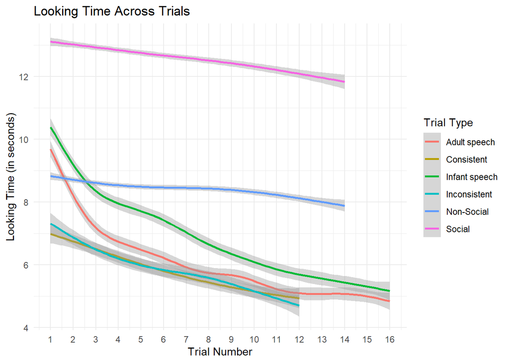

```r
ggplot(data_rq3, aes(x = testing_trial, y = looking_time, color = trial_type)) +
  geom_smooth(se = TRUE) +
  scale_color_discrete(
    name = "Trial Type",
    labels = c(
      "ADS" = "Adult speech",
      "IDS" = "Infant speech",
      "consistent" = "Consistent",
      "inconsistent" = "Inconsistent",
      "nonsocial" = "Non-Social",
      "social" = "Social"
    )
  ) +
  labs(
    x = "Trial Number",
    y = "Looking Time (in seconds)",
    title = "Looking Time Across Trials"
  ) +
  scale_x_continuous(
    breaks = seq(1, max(data_rq3$testing_trial, na.rm = TRUE), by = 1)
  ) +
  theme_minimal()
```

### 3.2.1 Habituation by Project ID

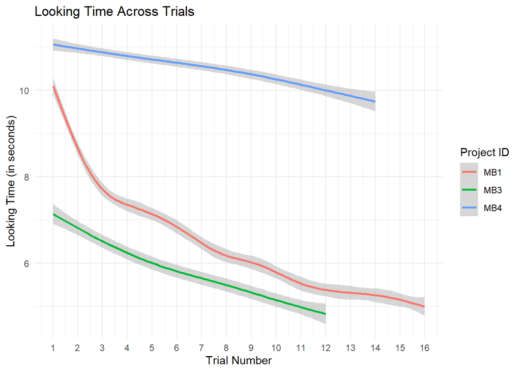

```r
ggplot(data_rq3, aes(x = testing_trial, y = looking_time, color = project_id)) +
  geom_smooth(se = TRUE) +
  scale_color_discrete(
    name = "Project ID") +
  labs(
    x = "Trial Number",
    y = "Looking Time (in seconds)",
    title = "Looking Time Across Trials"
  ) +
  scale_x_continuous(
    breaks = seq(1, max(data_rq3$testing_trial, na.rm = TRUE), by = 1)
  ) +
  theme_minimal()
```

#### 3.2.1.1 Habituation by Method

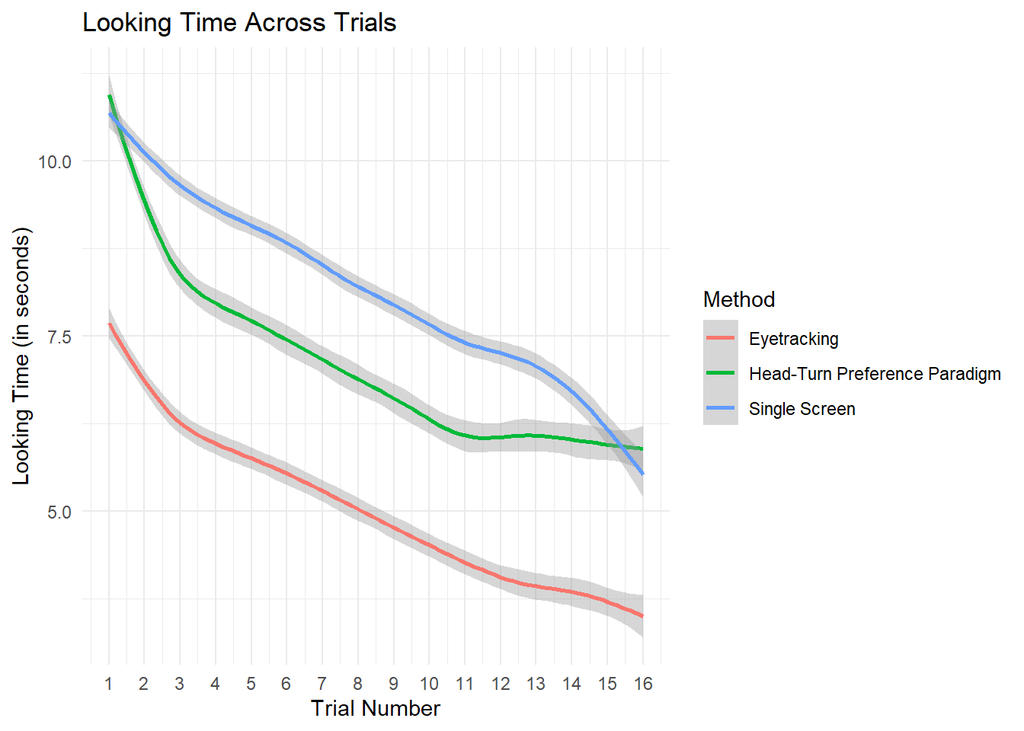

```r
ggplot(data_rq3, aes(x = testing_trial, y = looking_time, color = method)) +
  geom_smooth(se = TRUE) +
  scale_color_discrete(
    name = "Method",
    labels = c(
      "eyetracking" = "Eyetracking",
      "hpp" = "Head-Turn Preference Paradigm",
      "singlescreen" = "Single Screen")
  ) +
  labs(
    x = "Trial Number",
    y = "Looking Time (in seconds)",
    title = "Looking Time Across Trials"
  ) +
   scale_x_continuous(
    breaks = seq(1, max(data_rq3$testing_trial, na.rm = TRUE), by = 1)
  ) +
  theme_minimal()
```

### 3.2.2 Habituation by Caregiver Seat

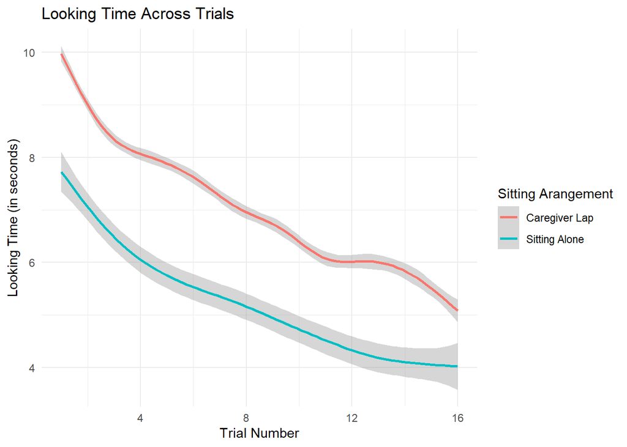

```r
ggplot(data_rq3 %>% dplyr::filter(!is.na(caregiver_seat)),
       aes(x = testing_trial, y = looking_time, color = caregiver_seat)) +
  geom_smooth(se = TRUE) +
  scale_color_discrete(
    name = "Sitting Arangement",
    labels = c(
      "caregiver_lap_only" = "Caregiver Lap",
      "seat_alone_only" = "Sitting Alone",
      "changed_throughout" = "Changed Throughout")
  ) +
  labs(
    x = "Trial Number",
    y = "Looking Time (in seconds)",
    title = "Looking Time Across Trials"
  ) +
  theme_minimal()
```

## 3.3 Distribution Analysis: Checking for Confounds

A critical step in this analysis is determining whether caregiver seating is a truly independent variable or a proxy for other methodological choices. As noted in the sources, there is a significant structural imbalance in the ManyBabies dataset: infants sitting alone are heavily overrepresented in eyetracking data, while those on a caregiver’s lap are the standard in HPP and single-screen paradigms.

### 3.3.1 Visualizing the Structural Imbalance

The following visualizations assess how seating arrangements are distributed across the three ManyBabies projects, the various experimental methods, and infant age groups. These plots reveal whether “Sitting Alone” is clustered within specific technical or developmental contexts.

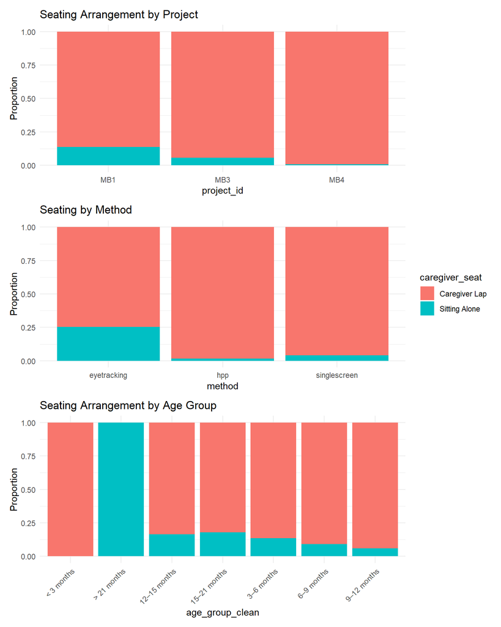

Figure 1: Proportional distribution of seating arrangement across study dimensions

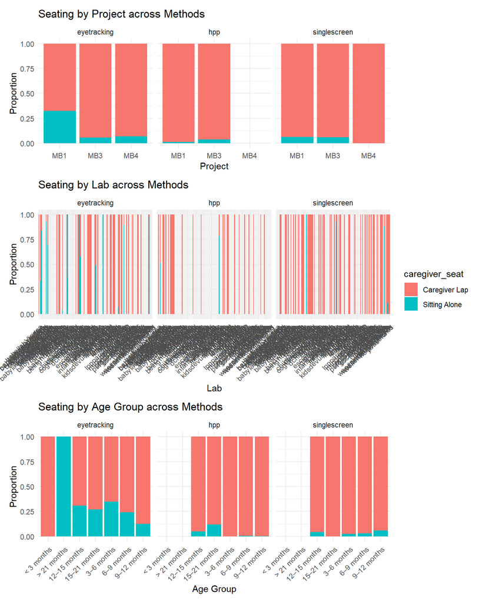

Figure 2: Proportional distribution of seating arrangement across study dimensions

```r
p1 <- ggplot(data_rq3, aes(x = project_id, fill = caregiver_seat)) +
  geom_bar(position = "fill") + labs(title = "Seating Arrangement by Project", y = "Proportion") + theme_minimal()

p2 <- ggplot(data_rq3, aes(x = method, fill = caregiver_seat)) +
  geom_bar(position = "fill") + labs(title = "Seating by Method", y = "Proportion") + theme_minimal()

p3 <- ggplot(data_rq3, aes(x = age_group_clean, fill = caregiver_seat)) +
  geom_bar(position = "fill") + labs(title = "Seating Arrangement by Age Group", y = "Proportion") +
  theme_minimal() + theme(axis.text.x = element_text(angle = 45, hjust = 1))

# Plot method and project_id and lab_id
p3 <- ggplot(data_rq3, aes(x = age_group_clean, fill = caregiver_seat)) +
  geom_bar(position = "fill") + labs(title = "Seating Arrangement by Age Group", y = "Proportion") +
  theme_minimal() + theme(axis.text.x = element_text(angle = 45, hjust = 1))

(p1 / p2 / p3) + plot_layout(guides = "collect")

# Method × Project (faceted)
p4 <- ggplot(data_rq3, aes(x = project_id, fill = caregiver_seat)) +
  geom_bar(position = "fill") +
  facet_wrap(~ method) +
  labs(title = "Seating by Project across Methods",
       y = "Proportion", x = "Project") +
  theme_minimal()

# Lab x Method (faceted)
p5 <- ggplot(data_rq3, aes(x = lab_id, fill = caregiver_seat)) +
  geom_bar(position = "fill") +
  facet_wrap(~ method) +
  labs(title = "Seating by Lab across Methods",
       y = "Proportion", x = "Lab") +
  theme_minimal() +
  theme(axis.text.x = element_text(angle = 45, hjust = 1))

# Age x Method
p6 <- ggplot(data_rq3, aes(x = age_group_clean, fill = caregiver_seat)) +
  geom_bar(position = "fill") +
  facet_wrap(~ method) +
  labs(title = "Seating by Age Group across Methods",
       y = "Proportion", x = "Age Group") +
  theme_minimal() +
  theme(axis.text.x = element_text(angle = 45, hjust = 1))

(p4 / p5 / p6) +
  plot_layout(guides = "collect")
```